# Implementando ICs

Iann Carvalho Barbosa

## Os dados

```r
set.seed(12345)

lastfm = read_csv(here::here("data/experimento-lastfm.csv"),
                  col_types = cols(.default = col_double(),
                                   user = col_character()))

lastfm = lastfm %>%
  na.omit() %>%
  mutate(news_old = news/(news+old))

glimpse(lastfm)
```

```
## Observations: 11,988
## Variables: 16
## $ user           <chr> "00blixt", "0ctane", "0sebastian0", "0xkirill", "…
## $ ecletic        <dbl> 1159.4960, 3439.8373, 1611.4464, 697.0974, 1660.1…
## $ clusters_total <dbl> 37, 155, 68, 37, 72, 93, 163, 150, 88, 132, 130, …
## $ clusters       <dbl> 19, 57, 25, 13, 31, 37, 64, 59, 27, 58, 62, 12, 3…
## $ media_pop      <dbl> 5.536362, 4.726167, 5.804086, 4.997963, 5.800357,…
## $ mediana_pop    <dbl> 5.660406, 4.730935, 5.896073, 5.214290, 5.865121,…
## $ dp_pop         <dbl> 0.6852190, 0.8819529, 0.6167104, 0.8685811, 0.544…
## $ news           <dbl> 38, 32, 24, 36, 28, 25, 30, 28, 14, 22, 27, 21, 2…
## $ news_total     <dbl> 38, 32, 24, 36, 28, 25, 30, 28, 14, 22, 27, 21, 2…
## $ old            <dbl> 116, 130, 10, 46, 128, 95, 228, 53, 46, 118, 90, …
## $ old_total      <dbl> 119, 141, 13, 71, 133, 167, 256, 63, 52, 125, 102…
## $ count_sim      <dbl> 0.155514371, 0.074823398, -0.123188406, 0.0841938…
## $ tempo_sim      <dbl> 0.208395596, -0.020325875, -0.043478261, -0.00160…
## $ count_pop      <dbl> 0.26923104, 0.13144651, -0.16666667, 0.09372521, …
## $ tempo_pop      <dbl> 0.08303680, -0.14228113, -0.11594203, 0.13012993,…
## $ news_old       <dbl> 0.2467532, 0.1975309, 0.7058824, 0.4390244, 0.179…
```

## Proporção de artistas novos e popularidade

Utilizaremos ICs para estimar duas métricas sobre os usuários do LastFM em geral durante um período de 6 meses. Em ambos os casos faremos isso a partir de uma amostra de 300 usuários. As duas métricas são:

### 1. Qual a proporção de novos artistas em geral escutada por usuários?

```r
theta <- function(df) {
    df %>% pull(news_old) %>% mean()
}

theta_news_old = theta(lastfm)
```

```r
lastfm = lastfm %>%
  sample_n(300) %>%
  select(news, old, mediana_pop, news_old)

theta_c = theta(lastfm)
```

```r
bootstrap <- function(x){
    news_old = x %>%
      pull(news_old)

    boot_x = sample(news_old, size = NROW(news_old), replace = TRUE)

    return(mean(boot_x))
}

reamostragens = tibble(i = 1:4000) %>%
    mutate(theta_c_s = map_dbl(i, ~ bootstrap(lastfm)))
```

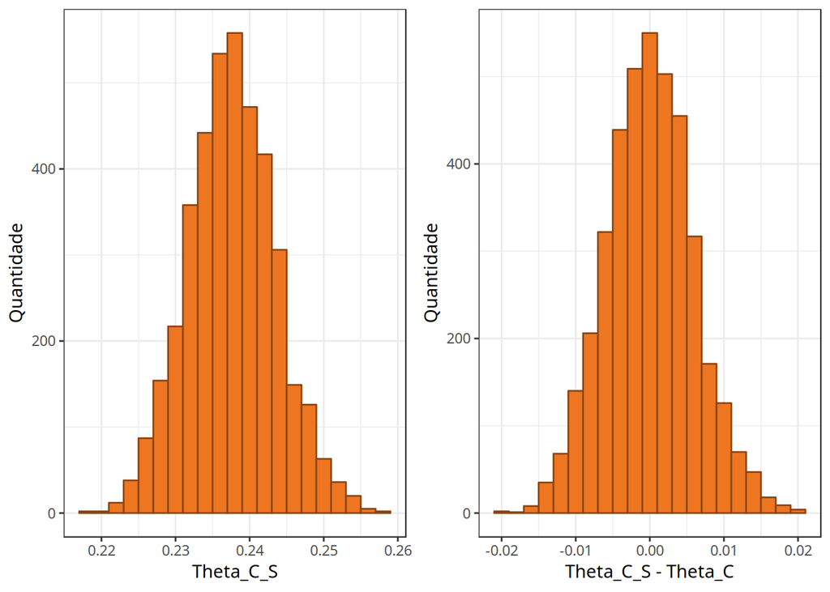

```r
p1 = reamostragens %>%
    ggplot(aes(x = theta_c_s)) +
    geom_histogram(binwidth = .002, colour = "chocolate4", fill = "chocolate2") +
    labs(x = "Theta_C_S", y = "Quantidade")

p2 = reamostragens %>%
    ggplot(aes(x = theta_c_s - theta_c)) +
    geom_histogram(binwidth = .002, colour = "chocolate4", fill = "chocolate2") +
    labs(x = "Theta_C_S - Theta_C", y = "Quantidade")

grid.arrange(p1, p2, ncol = 2)
```

```r
confianca <- 0.95
alpha <- 1 - confianca
intervalo = reamostragens %>%
  mutate(erro = theta_c_s - theta_c) %>%
  summarise(erro_i = quantile(erro, alpha / 2),
            erro_s = quantile(erro, 1 - alpha / 2),
            valor_i = theta_c + erro_i,
            valor_s = theta_c + erro_s)
intervalo
```

| erro_i | erro_s | valor_i | valor_s |
| --- | --- | --- | --- |
| -0.01123305 | 0.0122751 | 0.2263781 | 0.2498863 |

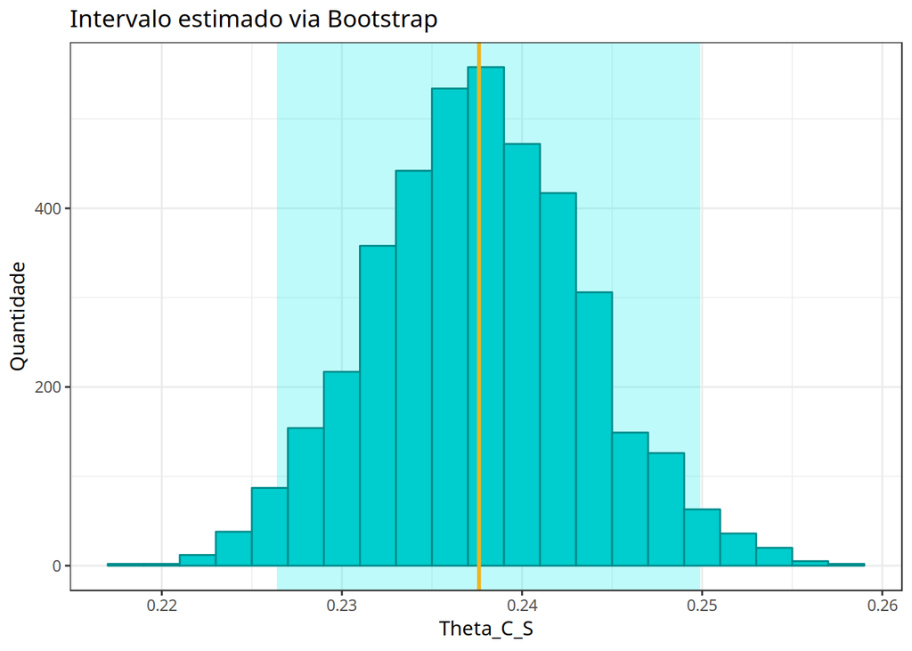

```r
ggplot() +
    geom_rect(data = intervalo, aes(xmin = valor_i, xmax = valor_s), ymin = -Inf, ymax = Inf, fill = "cyan2", alpha = .25) +
    geom_histogram(data = reamostragens, aes(theta_c_s), binwidth = .002, fill = "cyan3", colour = "cyan4") +
    geom_vline(xintercept = theta_c, color = "goldenrod2", size = 1) +
    labs(title = "Intervalo estimado via Bootstrap", x = "Theta_C_S", y = "Quantidade")
```

#### Usando bibliotecas Boot e Broom

```r
theta <- function(d, i) {
    agrupado = lastfm %>%
        slice(i) %>%
        summarise(media = mean(news_old)) %>%
        pull(media)
}

theta(lastfm, i = 1:NROW(lastfm))
```

```r
ci1 = boot(data = lastfm,
           statistic = theta,
           R = 4000) %>%
    tidy(conf.level = .95,
         conf.method = "bca",
         conf.int = TRUE)

ci1
```

| statistic | bias | std.error | conf.low | conf.high |
| --- | --- | --- | --- | --- |
| 0.2376112 | 1.368677e-06 | 0.0058982 | 0.2268928 | 0.2500849 |

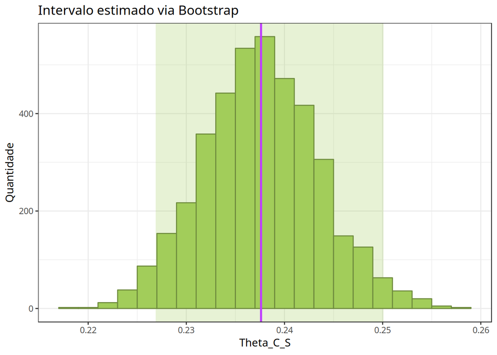

```r
ggplot() +
    geom_rect(data = ci1, aes(xmin = conf.low, xmax = conf.high), ymin = -Inf, ymax = Inf, fill = "darkolivegreen3", alpha = .25) +
    geom_histogram(data = reamostragens, aes(theta_c_s), binwidth = .002, fill = "darkolivegreen3", colour = "darkolivegreen4") +
    geom_vline(xintercept = theta_c, color = "darkorchid1", size = 1) +
    labs(title = "Intervalo estimado via Bootstrap", x = "Theta_C_S", y = "Quantidade")
```

Em média, os usuários do LastFM ouvem artistas novos em 23.7% das vezes, ou seja, escutam um novo artista a cada três artistas já conhecidos, aproximadamente. Esse resultado pode ser melhor expresso pelo intervalo [22.6%, 24,9%] com 95% de confiança.

### 2. Para os usuários que gostam de música muito pop (mediana_pop > 5), qual a correlação entre a popularidade mediana dos artistas escutado e a proporção dos artistas escutados que eram novos.

```r
funcao_theta_corr <- function(df) {
    x = df %>% filter(mediana_pop > 5)
    return(cor(x$mediana_pop, x$news_old))
}

theta_corr <- function(d, i) {
     agrupado = d %>% slice(i)

    corr = funcao_theta_corr(agrupado)
    return(corr)
}

theta_c_corr = funcao_theta_corr(lastfm)
theta_c_corr_lib = theta_corr(lastfm, i = 1:NROW(lastfm))
```

```r
outro_bootstrap <- function(x){
    boot_x <- sample_n(x, size = NROW(x), replace = TRUE)
    theta_c_s <- funcao_theta_corr(boot_x)

    return(theta_c_s)
}

reamostragens_2 = tibble(i = 1:4000) %>%
    mutate(theta_c_s = map_dbl(i, ~ outro_bootstrap(lastfm)))
```

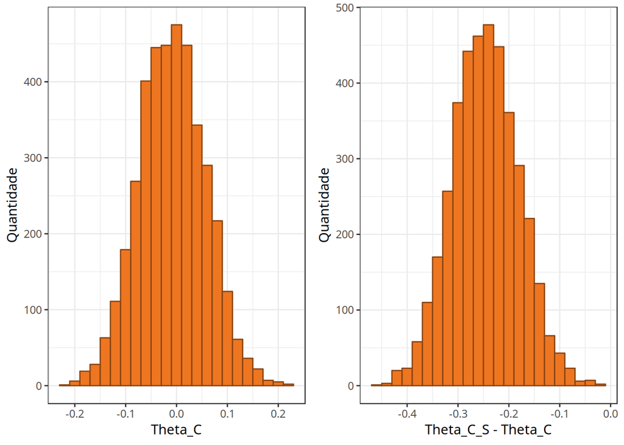

```r
p3 = reamostragens_2 %>%
    ggplot(aes(x = theta_c_s)) +
    geom_histogram(binwidth = .02, colour = "chocolate4", fill = "chocolate2") +
    labs(x = "Theta_C", y = "Quantidade")

p4 = reamostragens_2 %>%
    ggplot(aes(x = theta_c_s - theta_c)) +
    geom_histogram(binwidth = .02, colour = "chocolate4", fill = "chocolate2") +
    labs(x = "Theta_C_S - Theta_C", y = "Quantidade")

grid.arrange(p3, p4, ncol = 2)
```

```r
confianca = 0.95
alpha = 1 - confianca

intervalo_2 = reamostragens_2 %>%
  mutate(erro = theta_c_s - theta_c) %>%
  summarise(erro_i = quantile(erro, alpha / 2),
            erro_s = quantile(erro, 1 - alpha / 2),
            valor_i = theta_c + erro_i,
            valor_s = theta_c + erro_s)

intervalo_2
```

| erro_i | erro_s | valor_i | valor_s |
| --- | --- | --- | --- |
| -0.3704417 | -0.1183818 | -0.1328305 | 0.1192294 |

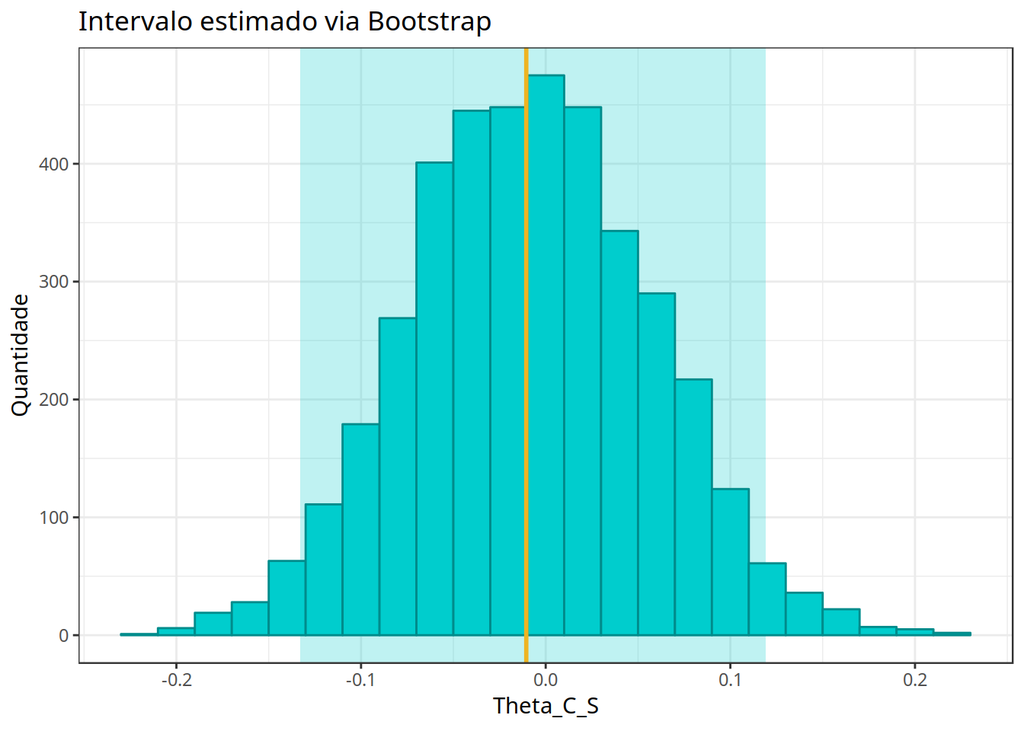

```r
ggplot() +
    geom_rect(data = intervalo_2, aes(xmin = valor_i, xmax = valor_s), ymin = -Inf, ymax = Inf, fill = "cyan3", alpha = .25) +
    geom_histogram(data = reamostragens_2, aes(theta_c_s), binwidth = .02, fill = "cyan3", colour = "cyan4") +
    geom_vline(xintercept = theta_c_corr, color = "goldenrod2", size = 1) +
    labs(title = "Intervalo estimado via Bootstrap", x = "Theta_C_S", y = "Quantidade")
```

#### Usando bibliotecas Boot e Broom

```r
intervalo_2_lib = lastfm %>%
  boot(statistic = theta_corr, R = 4000) %>%
  tidy(conf.level = .95, conf.int = TRUE)

intervalo_2_lib
```

| statistic | bias | std.error | conf.low | conf.high |
| --- | --- | --- | --- | --- |
| -0.01052332 | 0.00303096 | 0.06619325 | -0.1369348 | 0.1205093 |

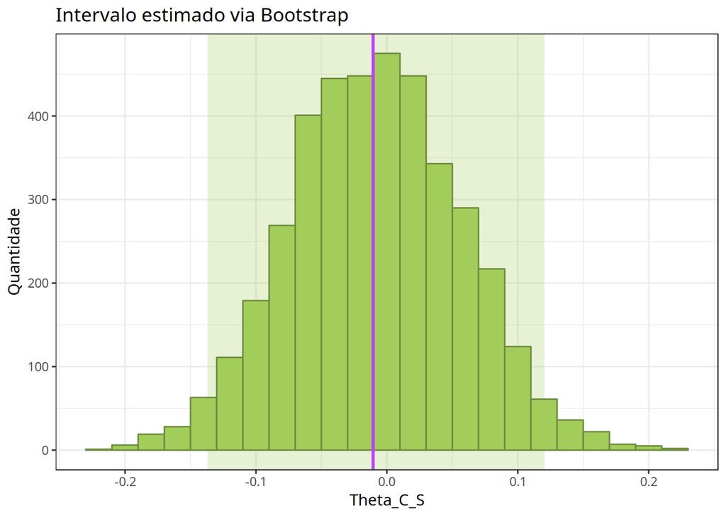

```r
ggplot() +
    geom_rect(data = intervalo_2_lib, aes(xmin = conf.low, xmax = conf.high), ymin = -Inf, ymax = Inf, fill = "darkolivegreen3", alpha = .25) +
    geom_histogram(data = reamostragens_2, aes(theta_c_s), binwidth = .02, fill = "darkolivegreen3", colour = "darkolivegreen4") +
    geom_vline(xintercept = theta_c_corr, color = "darkorchid1", size = 1) +
    labs(title = "Intervalo estimado via Bootstrap", x = "Theta_C_S", y = "Quantidade")
```

A correlação entre a popularidade dos artistas escutados pelos usuários do LastFM e a proporção de novos artistas que escutam é, em média, de -0.01 quando esses usuários escutam artistas muito populares. Portanto, não parece existir correlação entre essas duas variáveis nesse caso. Ainda, o valor da correlação encontrada pode ser melhor expressa pelo intervalo [-0.14, 0.12] com 95% de confiança.